# Itkonen Structures 50 Years On

# Introduction

## Itkonen’s Original Results

Before continuing, it’s worth noting Itkonen’s original results, which he published in 1976.

| Item | Voice | Type | Rate of Nominative (x/100) |
| --- | --- | --- | --- |
| harvinainen | active | existential | 25 |
|  | active | predicative | 64 |
|  | passive | existential | 52 |
|  | passive | predicative | 84 |
| jokin | active | existential | 37 |
|  | passive | existential | 83 |
| kappalainen | active | existential | 9 |
|  | active | predicative | 67 |
|  | passive | existential | 64 |
|  | passive | predicative | 72 |
| persikka | active | existential | 2 |
|  | active | predicative | 70 |
|  | passive | existential | 46 |
|  | passive | predicative | 83 |
| persoonallinen | active | existential | 84 |
|  | passive | existential | 93 |
| tulipalo | active | existential | 2 |
|  | passive | existential | 34 |
| valtio | active | existential | 34 |
|  | active | predicative | 71 |
|  | passive | existential | 68 |
|  | passive | predicative | 80 |

# Methods

## Stimuli

The first 22 trials of the study contained stimuli identical to that of Itkonen (1976). There were 7 stimulus frames, of which 4 appeared in all 4 possible voice & structure combinations:

- Active-Existential
- Active-Predicative
- Passive-Existential
- Passive-Predicative

The remaining 3 stimulus frames occurred only in the existential forms.

We additionally included two re-formulated versions of the ‘jokin’ stimulus item, due to Itkonen’s original wording being judged as non-standard by the third author.

Finally, we included three attention check items in the second half of the study, all of which asked participants to inflect the copular verb for different persons.

All modifications to the study (negated sentences, ‘jokin’ restructures, and attention checks) were included in the second half so as to be as faithful to Itkonen’s original study as possible.

## Procedure

After providing informed consent, participants were instructed that they would be reading 40 sentences which needed to be completed, and that they should select one of the options provided to best complete the sentence. They then completed an example trial with a prescriptively correct answer, on the basis of verb inflection.

After this, participants proceeded through the 40 trials, selecting one of two or three presented options to complete the sentence. The first 22 replicated Itkonen’s original study; items in this chunk were randomized between participants, and the order of options provided were also randomized. The last 18 items, which deviated from and added on to Itkonen’s study, were similarly randomized.

After completing the main study, participants were presented with a demographic questionnaire, which asked about age, education, gender, and county of Finland from which the participant came. All questions were optional.

A link to the experiment can be found [here](https://branpap.github.io/itkonen-replication/experiment/experiment.html). This version does **not** record responses, and is for demonstration purposes only.

# Results

## Replication Study

In our faithful replication of Itkonen’s original study, we find similar patterns to those in the original study, with regard to voice, structure, and item effects. We take each of these in turn here, before turning to the issue of changes between Itkonen’s results and our own.

### Voice

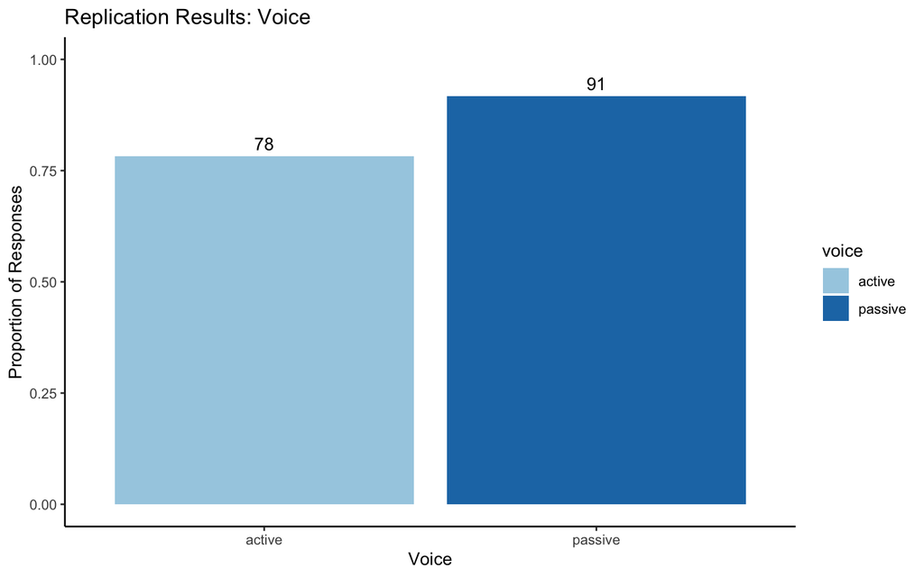

### Structure

[figure not shown]

### Crossed Voice x Structure

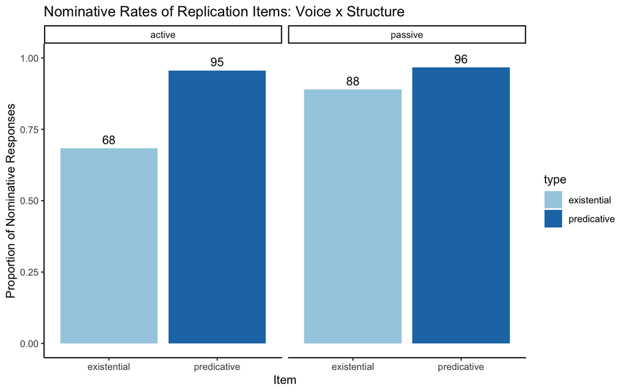

```r
ReplicationOnly %>%
  group_by(type,voice,responseCase) %>%
  count() %>%
  pivot_wider(values_from = n, names_from = responseCase) %>%
  summarize(nomRate = nom/(nom+gen)) %>%
  ggplot(aes(x=reorder(type, nomRate),y=nomRate, fill=type)) +
  geom_bar(stat="identity") +
  geom_text(aes(x=type,y=nomRate, vjust =-.5, label=trunc(nomRate*10^2))) +
  labs(x="Item", y="Proportion of Nominative Responses", title="Nominative Rates of Replication Items: Voice x Structure") +
  theme(legend.position = "none") +
  scale_fill_brewer(palette="Paired") +
  facet_wrap(~voice) +
  theme_classic() +
  ylim(0,1)
```

### Items

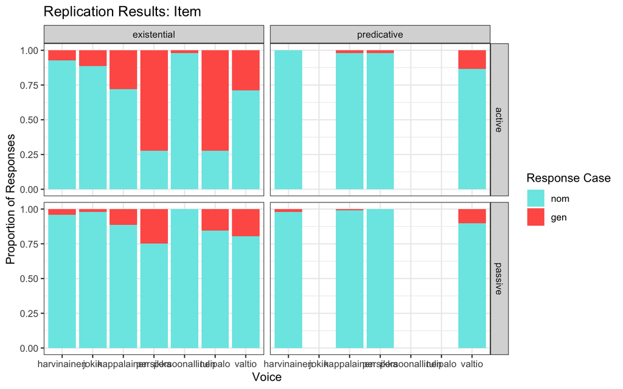

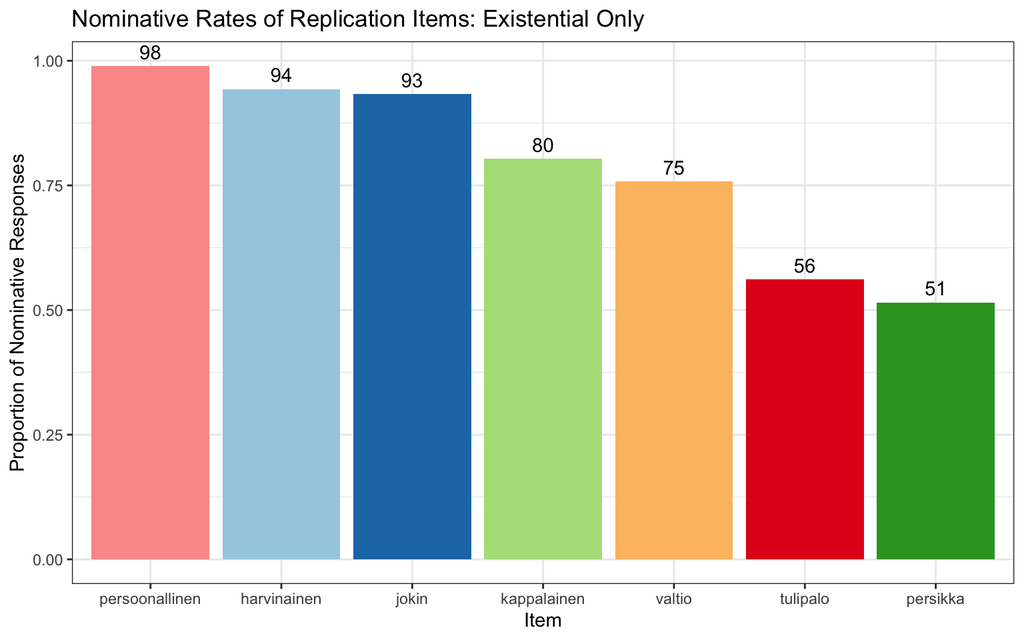

```r
ReplicationOnly %>%
  filter(type=="existential") %>%
  group_by(item,responseCase) %>%
  count() %>%
  pivot_wider(values_from = n, names_from = responseCase) %>%
  summarize(nomRate = nom/(nom+gen)) %>%
  ggplot(aes(x=reorder(item, -nomRate),y=nomRate, fill=item)) +
  geom_bar(stat="identity") +
  geom_text(aes(x=item,y=nomRate, vjust =-.5, label=trunc(nomRate*10^2))) +
  labs(x="Item", y="Proportion of Nominative Responses", title="Nominative Rates of Replication Items: Existential Only") +
  theme(legend.position = "none") +
  scale_fill_brewer(palette="Paired")
```

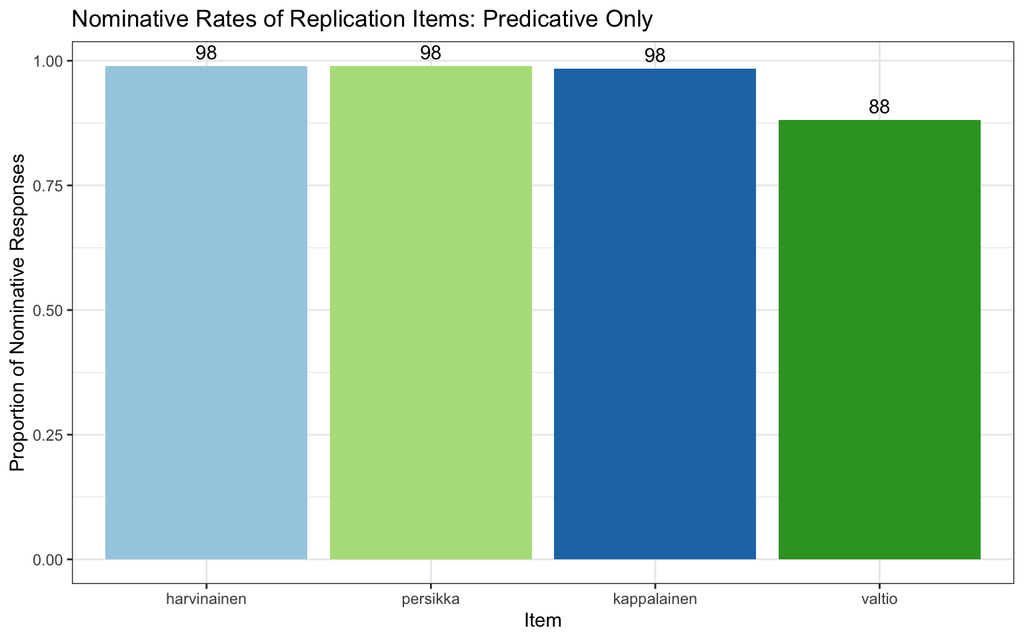

```r
ReplicationOnly %>%
  filter(type=="predicative") %>%
  group_by(item,responseCase) %>%
  count() %>%
  pivot_wider(values_from = n, names_from = responseCase) %>%
  summarize(nomRate = nom/(nom+gen)) %>%
  ggplot(aes(x=reorder(item, -nomRate),y=nomRate, fill=item)) +
  geom_bar(stat="identity") +
  geom_text(aes(x=item,y=nomRate, vjust =-.5, label=trunc(nomRate*10^2))) +
  labs(x="Item", y="Proportion of Nominative Responses", title="Nominative Rates of Replication Items: Predicative Only") +
  theme(legend.position = "none") +
  scale_fill_brewer(palette="Paired")
```

### Demographic Factors

*Age*

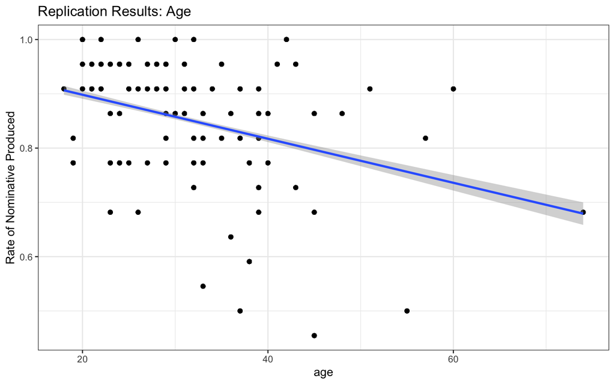

*Education*

[figure not shown]

### Changes Over Time

| Item | Voice | Structure | Nominative Proportion (1976) | Nominative Proportion (2022) | Change (1976 -> 2022) |
| --- | --- | --- | --- | --- | --- |
| harvinainen | active | existential | 25 | 92 | 67 |
| harvinainen | active | predicative | 64 | 100 | 36 |
| harvinainen | passive | existential | 52 | 95 | 43 |
| harvinainen | passive | predicative | 84 | 97 | 13 |
| jokin | active | existential | 37 | 88 | 51 |
| jokin | passive | existential | 83 | 97 | 14 |
| kappalainen | active | existential | 9 | 72 | 63 |
| kappalainen | active | predicative | 67 | 97 | 30 |
| kappalainen | passive | existential | 64 | 88 | 24 |
| kappalainen | passive | predicative | 72 | 98 | 26 |

[output cut: 12 more lines]

## Additional Items

### Negative Structures

```r
neg <- itkonen %>%
  filter(polarity == "negative")
```

# Working Space

[figure not shown]

```r
ReplicationOnly <- itkonen %>%
  filter(polarity == "positive") %>%
  filter(item != "jokin2")
```

```r
replicationItems <- ReplicationOnly %>%
  group_by(item,voice,type,responseCase) %>%
  count() %>%
  pivot_wider(names_from = responseCase,values_from = n) %>%
  replace_na(list(gen=0)) %>%
  summarize(itemNomRate = nom/(nom+gen),
            itemGenRate = 1-itemNomRate)
```

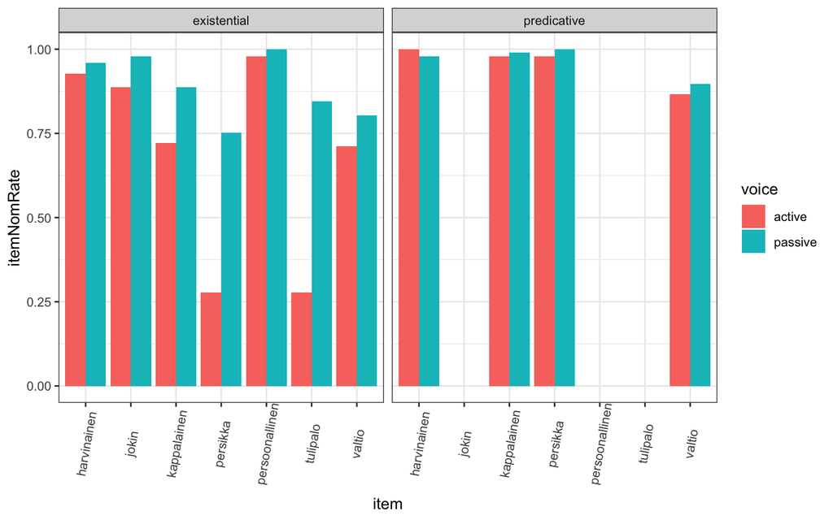

```r
replicationItems %>%
  ggplot(aes(x=item,y=itemNomRate,fill=voice)) +
  geom_bar(stat = "identity",position = position_dodge()) +
  facet_wrap(~type) +
  theme(axis.text.x = element_text(angle=80,vjust = .6))
```

```r
compItems <- left_join(itkonenOriginal,replicationItems)
compItems <- compItems %>%
  mutate(itemNomRate = trunc(itemNomRate*10^2),
         itemGenRate = trunc(itemGenRate*10^2),
         itemNomRateOriginal = trunc(itemNomRateOriginal*10^2),
         itemGenRateOriginal = trunc(itemGenRateOriginal*10^2),
         nomChange = itemNomRate - itemNomRateOriginal) %>%
  select(-c("itemGenRate","itemGenRateOriginal"))
```

```r
compItems %>%
  rename("Item" = "item",
         "Voice" = "voice",
         "Structure" = "type",
         "Nominative Proportion (1976)" = "itemNomRateOriginal",
         "Nominative Proportion (2022)" = "itemNomRate",
         "Change (1976 -> 2022)" = "nomChange") %>%
  group_by(Item) %>%
  slice(1:4) %>%
  select(Item, everything()) %>%
  collapse_rows_df(Item) %>%
  formattable(align = c("l"), list(
  area(col = "Change (1976 -> 2022)") ~ color_tile("transparent", customGreen)))
```

| Item | Voice | Structure | Nominative Proportion (1976) | Nominative Proportion (2022) | Change (1976 -> 2022) |
| --- | --- | --- | --- | --- | --- |
| harvinainen | active | existential | 25 | 92 | 67 |
|  | active | predicative | 64 | 100 | 36 |
|  | passive | existential | 52 | 95 | 43 |
|  | passive | predicative | 84 | 97 | 13 |
| jokin | active | existential | 37 | 88 | 51 |
|  | passive | existential | 83 | 97 | 14 |
| kappalainen | active | existential | 9 | 72 | 63 |
|  | active | predicative | 67 | 97 | 30 |
|  | passive | existential | 64 | 88 | 24 |
|  | passive | predicative | 72 | 98 | 26 |
| persikka | active | existential | 2 | 27 | 25 |
|  | active | predicative | 70 | 97 | 27 |
|  | passive | existential | 46 | 75 | 29 |
|  | passive | predicative | 83 | 100 | 17 |
| persoonallinen | active | existential | 84 | 97 | 13 |
|  | passive | existential | 93 | 100 | 7 |
| tulipalo | active | existential | 2 | 27 | 25 |
|  | passive | existential | 34 | 84 | 50 |
| valtio | active | existential | 34 | 71 | 37 |
|  | active | predicative | 71 | 86 | 15 |
|  | passive | existential | 68 | 80 | 12 |
|  | passive | predicative | 80 | 89 | 9 |

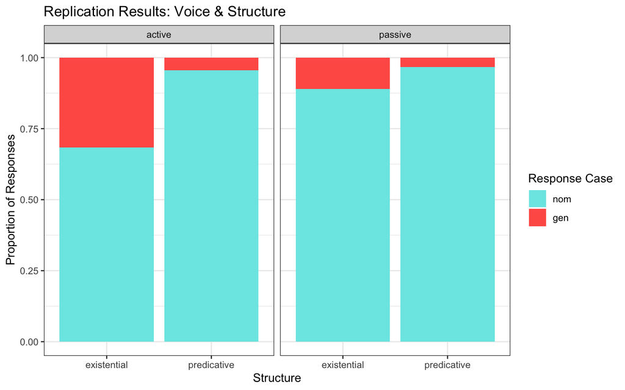

```r
ReplicationOnly %>%
  ggplot(aes(x=type,fill=responseCase)) +
  geom_bar(position='fill') +
  theme_bw() +
  facet_wrap(~voice) +
  labs(x="Structure",y="Proportion of Responses",fill="Response Case",title="Replication Results: Voice & Structure") +
  scale_fill_manual(values = bran_palette, limits=c("nom","gen"))
```

```r
ReplicationOnly <- ReplicationOnly %>%
  mutate(ResponseBinary = case_when(
    responseCase == "nom" ~ 1,
    responseCase == "gen" ~ 0,
   ))
```

```r
ReplicationModel = glmer(ResponseBinary ~ voice*type + (1|workerid) + (1|item),data=ReplicationOnly,family="binomial")
```

```r
summary(ReplicationModel)
```

```
## Generalized linear mixed model fit by maximum likelihood (Laplace
##   Approximation) [glmerMod]
##  Family: binomial  ( logit )
## Formula: ResponseBinary ~ voice * type + (1 | workerid) + (1 | item)
##    Data: ReplicationOnly
##
##      AIC      BIC   logLik deviance df.resid
##   1227.8   1261.8   -607.9   1215.8     2128
##
## Scaled residuals:
##      Min       1Q   Median       3Q      Max
## -10.6431   0.0542   0.1425   0.3015   2.8079
##
## Random effects:
##  Groups   Name        Variance Std.Dev.
##  workerid (Intercept) 1.545    1.243
##  item     (Intercept) 3.165    1.779
## Number of obs: 2134, groups:  workerid, 97; item, 7
##
## Fixed effects:
##                              Estimate Std. Error z value Pr(>|z|)
## (Intercept)                    1.4134     0.6988   2.023 0.043111 *
## voicepassive                   1.9865     0.1918  10.358  < 2e-16 ***
## typepredicative                3.3495     0.3118  10.742  < 2e-16 ***
## voicepassive:typepredicative  -1.6676     0.4439  -3.756 0.000172 ***
## ---
## Signif. codes:  0 '***' 0.001 '**' 0.01 '*' 0.05 '.' 0.1 ' ' 1
##
## Correlation of Fixed Effects:
##             (Intr) vcpssv typprd
## voicepassiv -0.053
## typepredctv -0.024  0.304
## vcpssv:typp  0.024 -0.427 -0.640
```

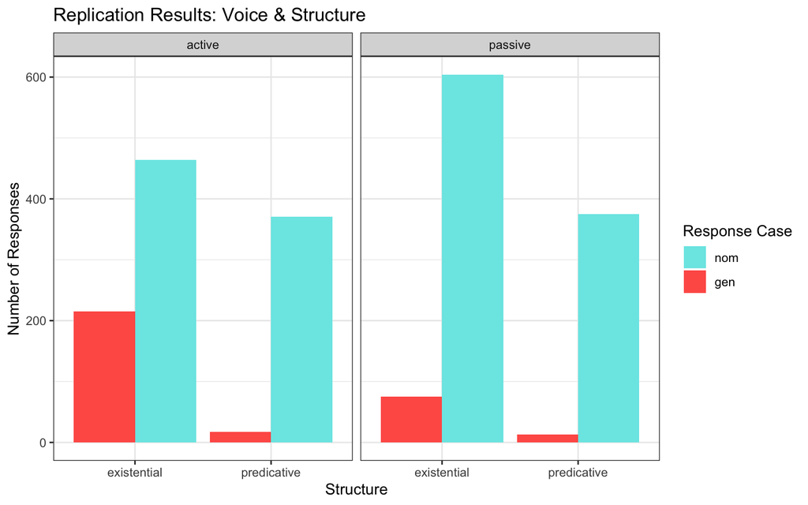

```r
ReplicationOnly %>%
  ggplot(aes(x=type,fill=responseCase)) +
  geom_bar(position=position_dodge()) +
  facet_wrap(~voice) +
  labs(x="Structure",y="Number of Responses",fill="Response Case",title="Replication Results: Voice & Structure") +
  scale_fill_manual(values = bran_palette, limits=c("nom","gen"))
```

## New Data

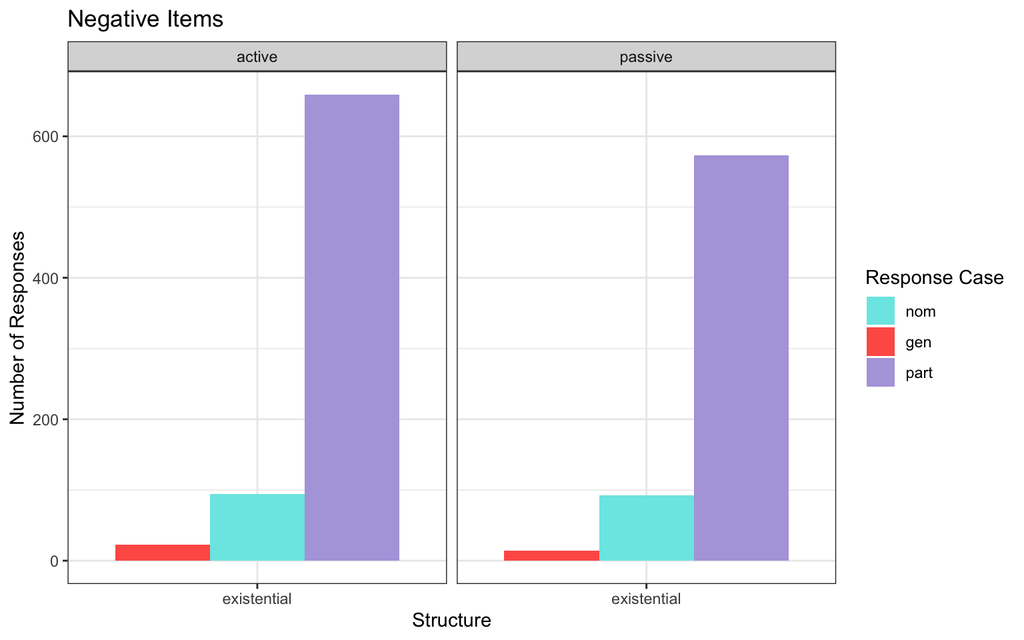

```r
itkonen %>%
  filter(polarity == "negative") %>%
  ggplot(aes(x=type,fill=responseCase)) +
  geom_bar(position=position_dodge()) +
  facet_wrap(~voice) +
  labs(x="Structure",y="Number of Responses",fill="Response Case",title="Negative Items") +
  scale_fill_manual(values = bran_palette, limits=c("nom","gen","part"))
```

```r
neg <- itkonen %>%
  filter(polarity == "negative")
```

## Demographic

```r
ItkonenDemographics <- ReplicationOnly %>%
  group_by(workerid) %>%
  summarize(comments = paste(unique(comments)),
         age = paste(unique(age)),
         gender = paste(unique(as.factor(gender))),
         region = paste(unique(as.factor(region))),
         education = paste(unique(as.factor(education))))
```

```r
table(ItkonenDemographics$region)
```

```
##
##     Etelä-Karjala   Etelä-Pohjanmaa        Etelä-Savo            Kainuu
##                 1                 2                 2                 5
##        Kanta-Häme   Keski-Pohjanmaa       Keski-Suomi             Lappi
##                 3                 2                 3                 2
##              null       Päijät-Häme         Pirkanmaa         Pohjanmaa
##                 2                 7                 6                 1
##   Pohjois-Karjala Pohjois-Pohjanmaa      Pohjois-Savo         Satakunta
##                 2                 9                 3                 2
##           Uusimaa   Varsinais-Suomi
##                31                14
```

### Comments

```r
ItkonenDemographics %>%
  filter(!is.na(comments))
```

```
## # A tibble: 97 × 6
##    workerid comments                               age   gender region education
##       <int> <chr>                                  <chr> <chr>  <chr>  <chr>
##  1     1025 ""                                     23    Male   Päijä… 0
##  2     1026 ""                                     24    Male   Päijä… 1
##  3     1027 "ei palautetta"                        37    Female Pirka… 4
##  4     1028 ""                                     38    Female Etelä… 2
##  5     1029 ""                                     51    Male   Varsi… 3
##  6     1030 ""                                     20    Female Pohjo… 2
##  7     1031 ""                                     21    Female Uusim… 0
##  8     1032 ""                                     60    Male   Uusim… 3
##  9     1033 ""                                     29    Male   Pohjo… -1
## 10     1034 "Jotkin lauseet olivat yllättävän han… 29    Male   Pohjo… 3
## # … with 87 more rows
```

```r
ReplicationOnly %>%
  group_by(item,voice,type,responseCase) %>%
  count() %>%
  pivot_wider(names_from = responseCase,values_from = n) %>%
  replace_na(list(gen=0,nom=0)) %>%
  summarize(NomRate = nom/(nom+gen),
            GenRate = 1-NomRate)
```

```
## # A tibble: 22 × 5
## # Groups:   item, voice [14]
##    item        voice   type        NomRate GenRate
##    <chr>       <chr>   <chr>         <dbl>   <dbl>
##  1 harvinainen active  existential   0.928  0.0722
##  2 harvinainen active  predicative   1      0
##  3 harvinainen passive existential   0.959  0.0412
##  4 harvinainen passive predicative   0.979  0.0206
##  5 jokin       active  existential   0.887  0.113
##  6 jokin       passive existential   0.979  0.0206
##  7 kappalainen active  existential   0.722  0.278
##  8 kappalainen active  predicative   0.979  0.0206
##  9 kappalainen passive existential   0.887  0.113
## 10 kappalainen passive predicative   0.990  0.0103
## # … with 12 more rows
```